# Variable Selection and Regression (part 2)

Ryan Miller

## Regression

- In supervised learning we use $\mathbf{X}$ to predict $Y$ via: $Y = f(\mathbf{X}) + \epsilon$
- For **linear regression**, $f(\mathbf{X}) = \mathbf{X} \mathbf{\beta}$ and $\epsilon_i \sim N(0,\sigma^2)$
- The linear regression model is fit (trained) by finding estimates $\hat{\mathbf{\beta}}$ which minimize the residual sum of squares:
  $$RSS = \sum_i (y_i - \mathbf{x}_i^T \hat{\mathbf{\beta}})^2$$

## Regression

- Often $\hat{\mathbf{\beta}}$ is a good, or even optimal, estimator of $\mathbf{\beta}$
- However, in many situations, $\hat{\mathbf{\beta}}$ is *not* a very good estimator. Examples include:
  - When the number of variables in $\mathbf{X}$ is large
  - When the variables of $\mathbf{X}$ are highly correlated
  - In these situations, $\hat{\mathbf{\beta}}$ can be unstable (high variability)

```r
pol <- readRDS(url("https://s3.amazonaws.com/pbreheny-data-sets/pollution.rds"))
kable(head(pol$X))
```

|  | Precip | Humidity | JanTemp | JulyTemp | Over65 | House | Educ | Sound | Density | NonWhite | WhiteCol | Poor | HC | NOX | SO2 |
| --- | --- | --- | --- | --- | --- | --- | --- | --- | --- | --- | --- | --- | --- | --- | --- |
| San Jose, CA | 13 | 71 | 49 | 68 | 7.0 | 3.36 | 12.2 | 90.7 | 2702 | 3.0 | 51.9 | 9.7 | 105 | 32 | 3 |
| Wichita, KS | 28 | 54 | 32 | 81 | 7.0 | 3.27 | 12.1 | 81.0 | 3665 | 7.5 | 51.6 | 13.2 | 4 | 2 | 1 |
| San Diego, CA | 10 | 61 | 55 | 70 | 7.3 | 3.11 | 12.1 | 88.9 | 3033 | 5.9 | 51.0 | 14.0 | 144 | 66 | 20 |
| Lancaster, PA | 43 | 54 | 32 | 74 | 10.1 | 3.38 | 9.5 | 79.2 | 3214 | 2.9 | 43.7 | 12.0 | 11 | 7 | 32 |
| Minneapolis, MN | 25 | 58 | 12 | 73 | 9.2 | 3.28 | 12.1 | 83.1 | 2095 | 2.0 | 51.9 | 9.8 | 20 | 11 | 26 |
| Dallas, TX | 35 | 54 | 46 | 85 | 7.1 | 3.22 | 11.8 | 79.9 | 1441 | 14.8 | 51.2 | 16.1 | 1 | 1 | 1 |

```r
## fit lm to scaled data, beta = effect of 1 std dev increase
summary(lm(pol$y ~ scale(pol$X)))
```

```
##
## Call:
## lm(formula = pol$y ~ scale(pol$X))
##
## Residuals:
##     Min      1Q  Median      3Q     Max
## -67.985 -17.987   0.881  19.260  86.881
##
## Coefficients:
##                      Estimate Std. Error t value Pr(>|t|)
## (Intercept)          940.3565     4.5072 208.634   <2e-16 ***
## scale(pol$X)Precip    19.0166     9.2189   2.063   0.0451 *
## scale(pol$X)Humidity   0.5700     6.2760   0.091   0.9280
## scale(pol$X)JanTemp  -19.6750    11.2673  -1.746   0.0878 .
## scale(pol$X)JulyTemp -14.7734     9.0535  -1.632   0.1099
## scale(pol$X)Over65   -13.2470    12.4235  -1.066   0.2921
## scale(pol$X)House    -14.4046     9.4361  -1.527   0.1340
## scale(pol$X)Educ     -14.4275    10.0265  -1.439   0.1572
## scale(pol$X)Sound     -3.3902     9.0882  -0.373   0.7109
## scale(pol$X)Density    5.3244     5.8569   0.909   0.3683
## scale(pol$X)NonWhite  39.7849    11.8291   3.363   0.0016 **
## scale(pol$X)WhiteCol  -0.8870     7.6629  -0.116   0.9084
## scale(pol$X)Poor      -0.6876    13.4177  -0.051   0.9594
## scale(pol$X)HC       -61.8228    45.1418  -1.370   0.1778
## scale(pol$X)NOX       62.0851    46.5707   1.333   0.1893
## scale(pol$X)SO2        5.4591     9.3473   0.584   0.5622
## ---
## Signif. codes:  0 '***' 0.001 '**' 0.01 '*' 0.05 '.' 0.1 ' ' 1
##
## Residual standard error: 34.91 on 44 degrees of freedom
## Multiple R-squared:  0.7651, Adjusted R-squared:  0.685
## F-statistic: 9.552 on 15 and 44 DF,  p-value: 2.16e-09
```

## Remedies - Subset Selection

- One solution is not to use all of the variables $\mathbf{X}$, selecting only a *subset of variables* to use in the model
- Many algorithmic approaches exist to variable selection, the simplest is the **best subsets** approach
  - Fit models for *all possible* combinations of the predictor variables
  - Use a metric (adjusted $R^2$, $AIC$, $BIC$, or cross-validation error) to select one of these models
  - Best subsets does not scale well when the number of predictors is large

## Friedman’s Benchmark Simulation

- To explore variable selection, we’ll introduce a well-known benchmark simulation setup:

$$y = 10sin(\pi x_1 x_2) + 20(x_3 - 0.5)^3 + 10x_4 + 5x_5 + N(0,1)$$

- There are five additional predictors, $x_6, \ldots, x_{10}$, that are *unrelated* with $y$ (ie: true coefficients of zero)
- All predictor variables, $x_1, \ldots, x_{10}$, are uniformly distributed between 0 and 1
- Friedman’s data setup is useful because it contains:
  - Variables that interact with each other ($x_1, x_2$)
  - A variable with a non-linear effect ($x_3$)
  - Variables with different sized linear effects ($x_4, x_5$)
  - Variables that contribute nothing ($x_6, \ldots, x_{10}$)

```r
set.seed(123)
sim <- mlbench.friedman1(100)
dim(sim$x)
```

```
## [1] 100  10
```

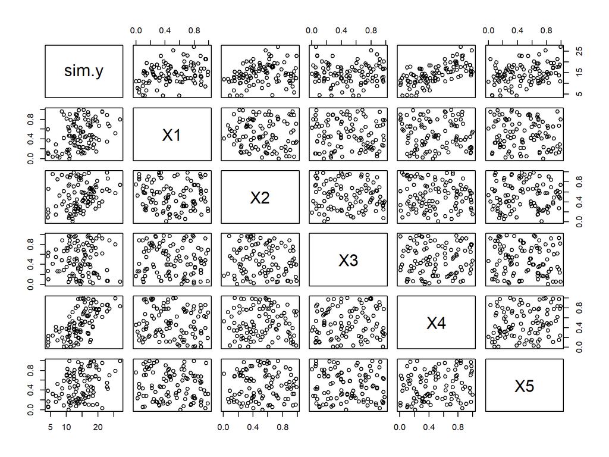

```r
pairs(data.frame(sim$y, sim$x)[,1:6])
```

## Best Subsets on Friedman’s Benchmark

- We will compare best subsets regression with blindly using all variables
- Because there are $2^{10} = 1024$ models to check when $p = 10$, we will illustrate best subsets by *only considering* variables: $\{x_4, x_5, x_6, x_7\}$
  - Recall that $x_4, x_5$ have true linear effects and *belong* in the model
  - Relatedly, $x_6, x_7$ are not relatd with $y$ and *don’t belong* in the model

```r
fit.control <- trainControl(method = "repeatedcv", number = 5, repeats = 10)
X <- sim$x
colnames(X) <- paste0("X",1:10)

best_subs <- bss(data.frame(X[,4:7]), sim$y, method = "lm", trControl = fit.control, verbose = FALSE, seed = 10)

kable(best_subs$perf_all) %>%
  kable_styling("striped", full_width = TRUE) %>%
  row_spec(which.min(best_subs$perf_all$RMSE), bold = T, color = "white", background = "#D7261E")
```

|  | var1 | var2 | var3 | var4 | RMSE | SE | nvar |
| --- | --- | --- | --- | --- | --- | --- | --- |
| 4 | X6 | X7 | NA | NA | 4.734353 | 0.0951339 | 2 |
| 6 | X5 | X7 | NA | NA | 4.464362 | 0.0703709 | 2 |
| 7 | X4 | X7 | NA | NA | 3.615149 | 0.0643924 | 2 |
| 9 | X5 | X6 | NA | NA | 4.459031 | 0.0700298 | 2 |
| 10 | X4 | X6 | NA | NA | 3.622241 | 0.0660675 | 2 |
| 11 | X4 | X5 | NA | NA | 3.474589 | 0.0530480 | 2 |
| 2 | X5 | X6 | X7 | NA | 4.514614 | 0.0753285 | 3 |
| 3 | X4 | X6 | X7 | NA | 3.660513 | 0.0659983 | 3 |
| 5 | X4 | X5 | X7 | NA | 3.515467 | 0.0533253 | 3 |
| 8 | X4 | X5 | X6 | NA | 3.510303 | 0.0540817 | 3 |
| 1 | X4 | X5 | X6 | X7 | 3.552755 | 0.0549539 | 4 |

## Remedies - Stepwise Selection

- A relatively modest number of predictors (ie: 10) leads to over 1,000 possible models
  - To make the best subsets approach doable, we needed to arbitrarily restrict ourselves to four varialbes
- Most of these models aren’t promising candidates, so an alternative approach is to only check certain variable combinations that show promise
- **Stepwise** selection algorithms are one of way of doing this
  - **Forward** stepwise algorithms start with an empty model and add (or later subtract) variables one at a time
  - **Backward** stepwise algorithms start with a full (saturated) model and substract (or later add) variables one at a time
- Because these algorithms scale fairly well, we can apply them to the full Friedman data:

```r
## Forward feature selection
forward_subs <- ffs(data.frame(X), sim$y, method = "lm", trControl = fit.control, verbose = FALSE, seed = 10)
```

```
## Note: No increase in performance found using more than 6 variables
```

```r
forward_subs$finalModel
```

```
##
## Call:
## lm(formula = .outcome ~ ., data = dat)
##
## Coefficients:
## (Intercept)           X1           X4           X5           X2
##      0.9542       7.8119       9.7966       4.9255       4.7073
##          X8           X9
##     -1.9586       1.7739
```

```r
## Recursive feature elimination (backwards selection)
ctrl <- rfeControl(functions = lmFuncs, method = "repeatedcv", number = 5, repeats = 10, verbose = FALSE)
backward_subs <- rfe(data.frame(X), sim$y, rfeControl = ctrl, seed = 10)
backward_subs$fit
```

```
##
## Call:
## lm(formula = y ~ ., data = tmp)
##
## Coefficients:
## (Intercept)           X4           X1           X5           X2
##       1.187       10.138        7.275        4.410        4.762
```

```r
## Compare them
resamps <- resamples(list(back = backward_subs, forward = forward_subs))
summary(resamps)
```

```
##
## Call:
## summary.resamples(object = resamps)
##
## Models: back, forward
## Number of resamples: 50
##
## MAE
##             Min.  1st Qu.   Median     Mean  3rd Qu.     Max. NA's
## back    1.080157 1.745725 2.054953 2.014560 2.256631 2.769732    0
## forward 1.355957 1.787709 2.009237 2.005027 2.196589 2.485581    0
##
## RMSE
##             Min.  1st Qu.   Median     Mean  3rd Qu.     Max. NA's
## back    1.315928 2.209824 2.573824 2.600215 3.019171 3.604832    0
## forward 1.631956 2.293498 2.535451 2.571960 2.830070 3.346459    0
##
## Rsquared
##              Min.   1st Qu.    Median      Mean   3rd Qu.      Max. NA's
## back    0.4011198 0.5843880 0.6949382 0.6912667 0.8041287 0.9169403    0
## forward 0.2529559 0.6534925 0.7088732 0.6979524 0.7683345 0.8633300    0
```

## Remedies - Principle Components Regression

- Another alternative is to derive a smaller set of independent predictor variables using principle components
- This is known as **principle components regression**:
  - Perform PCA
  - Fit a linear regression model using the first $P$ principle components as predictor variables

```r
df <- data.frame(y = sim$y, X)
pcreg.fit <- train(y ~ ., data = df, method = "pcr", trControl = fit.control, tuneGrid = data.frame(ncomp = 1:10), seed = 10)

## Alternatively, pre-process using PCA
set.seed(10)
pcpre.fit <- train(y ~ ., data = df, method = "lm", trControl = fit.control, preProcess = "pca")

resamps <- resamples(list(back = backward_subs, forward = forward_subs, pc = pcreg.fit, pc2 = pcpre.fit))
summary(resamps)
```

```
##
## Call:
## summary.resamples(object = resamps)
##
## Models: back, forward, pc, pc2
## Number of resamples: 50
##
## MAE
##             Min.  1st Qu.   Median     Mean  3rd Qu.     Max. NA's
## back    1.080157 1.745725 2.054953 2.014560 2.256631 2.769732    0
## forward 1.355957 1.787709 2.009237 2.005027 2.196589 2.485581    0
## pc      1.372384 1.898722 2.137618 2.105420 2.339477 2.970614    0
## pc2     1.530897 2.010030 2.282908 2.363710 2.531753 3.971561    0
##
## RMSE
##             Min.  1st Qu.   Median     Mean  3rd Qu.     Max. NA's
## back    1.315928 2.209824 2.573824 2.600215 3.019171 3.604832    0
## forward 1.631956 2.293498 2.535451 2.571960 2.830070 3.346459    0
## pc      1.671056 2.422472 2.651091 2.652999 3.054167 3.504408    0
## pc2     1.884479 2.668943 2.977155 3.003669 3.208692 4.705670    0
##
## Rsquared
##              Min.   1st Qu.    Median      Mean   3rd Qu.      Max. NA's
## back    0.4011198 0.5843880 0.6949382 0.6912667 0.8041287 0.9169403    0
## forward 0.2529559 0.6534925 0.7088732 0.6979524 0.7683345 0.8633300    0
## pc      0.3197668 0.5867978 0.7019811 0.6813823 0.7825410 0.9319581    0
## pc2     0.2087203 0.5550671 0.6246187 0.5999853 0.6725473 0.8332134    0
```

Remarks:

- By default, pre-processing will select the number of components necessary to retain 95% of the variability in $X$
- Using `method = "pcr"` will check various numbers of components (recall that `resamps` uses the optimal model produced by `train`)

## Problems with these methods

- Principle components regression can be effective, but it is difficult to interpret
- Stepwise selection algorithms are greedy, they don’t lead to globally optimal solutions
- Best subsets regression doesn’t scale well, it’s nearly impossible for even moderate $p$ (like 10)

## Advice

- For most applications of linear regression (small-ish $p$), manual model building is preferable to relying on algorithms
- Manual model building starts to become difficult when the number of available predictors becomes larger
  - Algorithms can provide a good starting point that can be further tweaked by the analyst
  - Next time we will discuss a better automated method (LASSO regression)
  - The final lab will go through a case study involving variable selection and model building